# CP Practical Machine Learning Report

Zack Gouttel

04/09/2020

# Intro

Using devices such as Jawbone Up, Nike FuelBand, and Fitbit it is now possible to collect a large amount of data about personal activity relatively inexpensively. These type of devices are part of the quantified self movement – a group of enthusiasts who take measurements about themselves regularly to improve their health, to find patterns in their behavior, or because they are tech geeks. One thing that people regularly do is quantify how much of a particular activity they do, but they rarely quantify how well they do it. In this project, our goal will be to use data from accelerometers on the belt, forearm, arm, and dumbell of 6 participants. They were asked to perform barbell lifts correctly and incorrectly in 5 different ways.

## Loading The data and the necessary packages

```r
library(caret)
```

```r
library(rpart)
library(rpart.plot)
library(RColorBrewer)
library(rattle)
library(randomForest)
library(gbm)
test_set<-read.csv("pml-testing (1).csv")
train_set<-read.csv("pml-training (1).csv")

#dim(train_set)
#dim(test_set)
```

## Paritioning

we’ll divide our Training set into 60% for training and 40% for testing

```r
inTrain <- createDataPartition(train_set$classe, p=0.6, list=FALSE)
training <- train_set[inTrain,]
testing <- train_set[-inTrain,]

#dim(training)
#dim(testing)
```

## Decision Tree Model

```r
DT_modfit <- train(classe ~ ., data = training, method="rpart")
```

Prediction using DTM:

```r
DT_prediction <- predict(DT_modfit, testing)
confusionMatrix(DT_prediction, testing$classe)
```

```
## Confusion Matrix and Statistics
##
##           Reference
## Prediction    A    B    C    D    E
##          A 1785  338   68  122   80
##          B   47  716   49   95  297
##          C  226  234  947  348  313
##          D  172  230  294  721  134
##          E    2    0   10    0  618
##
## Overall Statistics
##
##                Accuracy : 0.6101
##                  95% CI : (0.5992, 0.6209)
##     No Information Rate : 0.2845
##     P-Value [Acc > NIR] : < 2.2e-16
##
##                   Kappa : 0.5068
##
##  Mcnemar's Test P-Value : < 2.2e-16
##
## Statistics by Class:
##
##                      Class: A Class: B Class: C Class: D Class: E
## Sensitivity            0.7997  0.47167   0.6923  0.56065  0.42857
## Specificity            0.8917  0.92288   0.8270  0.87348  0.99813
## Pos Pred Value         0.7459  0.59468   0.4579  0.46486  0.98095
## Neg Pred Value         0.9180  0.87925   0.9271  0.91025  0.88581
## Prevalence             0.2845  0.19347   0.1744  0.16391  0.18379
## Detection Rate         0.2275  0.09126   0.1207  0.09189  0.07877
## Detection Prevalence   0.3050  0.15345   0.2636  0.19768  0.08030
## Balanced Accuracy      0.8457  0.69728   0.7596  0.71706  0.71335
```

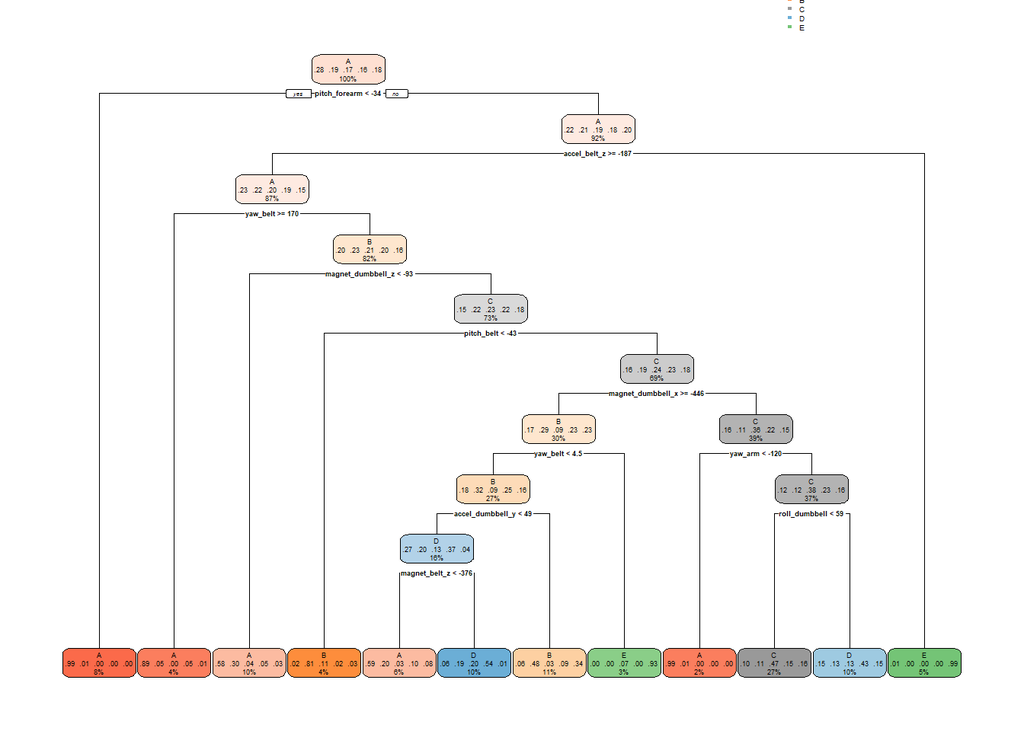

```r
rpart.plot(DT_modfit$finalModel, roundint=FALSE)
```

## Random Forest Model

```r
RF_modfit <- train(classe ~ ., data = training, method = "rf", ntree = 100)
```

Prediction using RFM:

```r
RF_prediction <- predict(RF_modfit, testing)
RF_pred_conf <- confusionMatrix(RF_prediction, testing$classe)
RF_pred_conf
```

```
## Confusion Matrix and Statistics
##
##           Reference
## Prediction    A    B    C    D    E
##          A 2226    8    0    0    0
##          B    4 1504   12    0    0
##          C    1    6 1353   20    2
##          D    0    0    3 1263    8
##          E    1    0    0    3 1432
##
## Overall Statistics
##
##                Accuracy : 0.9913
##                  95% CI : (0.989, 0.9933)
##     No Information Rate : 0.2845
##     P-Value [Acc > NIR] : < 2.2e-16
##
##                   Kappa : 0.989
##
##  Mcnemar's Test P-Value : NA
##
## Statistics by Class:
##
##                      Class: A Class: B Class: C Class: D Class: E
## Sensitivity            0.9973   0.9908   0.9890   0.9821   0.9931
## Specificity            0.9986   0.9975   0.9955   0.9983   0.9994
## Pos Pred Value         0.9964   0.9895   0.9790   0.9914   0.9972
## Neg Pred Value         0.9989   0.9978   0.9977   0.9965   0.9984
## Prevalence             0.2845   0.1935   0.1744   0.1639   0.1838
## Detection Rate         0.2837   0.1917   0.1724   0.1610   0.1825
## Detection Prevalence   0.2847   0.1937   0.1761   0.1624   0.1830
## Balanced Accuracy      0.9979   0.9941   0.9923   0.9902   0.9962
```

And we plot it here:

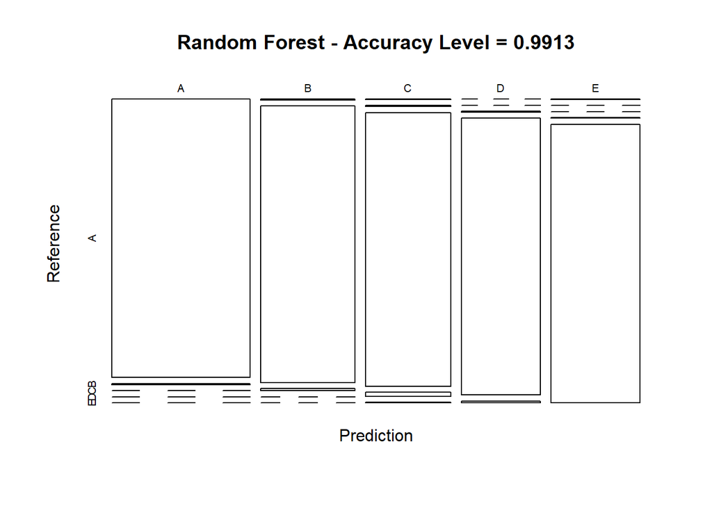

From the Confusion Matrix’s CI, we get a 99% accuracy most of the times so the RFM is satisfying our needs.

## Gradient Boosting Model

```r
GBM_modfit <- train(classe ~ ., data = training, method = "gbm", verbose = FALSE)
GBM_modfit$finalModel
```

```
## A gradient boosted model with multinomial loss function.
## 150 iterations were performed.
## There were 51 predictors of which 51 had non-zero influence.
```

```r
#GBM_prediction <- predict(GBM_modfit, testing, type = "class", n.trees = 5, type = link)
GBM_prediction <- predict(GBM_modfit, testing)

GBM_pred_conf <- confusionMatrix(GBM_prediction, testing$classe)
GBM_pred_conf
```

```
## Confusion Matrix and Statistics
##
##           Reference
## Prediction    A    B    C    D    E
##          A 2193   61    0    1    6
##          B   21 1406   48    8   21
##          C   12   49 1300   51   19
##          D    5    1   18 1210   23
##          E    1    1    2   16 1373
##
## Overall Statistics
##
##                Accuracy : 0.9536
##                  95% CI : (0.9487, 0.9582)
##     No Information Rate : 0.2845
##     P-Value [Acc > NIR] : < 2.2e-16
##
##                   Kappa : 0.9413
##
##  Mcnemar's Test P-Value : 1.97e-15
##
## Statistics by Class:
##
##                      Class: A Class: B Class: C Class: D Class: E
## Sensitivity            0.9825   0.9262   0.9503   0.9409   0.9521
## Specificity            0.9879   0.9845   0.9798   0.9928   0.9969
## Pos Pred Value         0.9699   0.9348   0.9085   0.9626   0.9856
## Neg Pred Value         0.9930   0.9823   0.9894   0.9885   0.9893
## Prevalence             0.2845   0.1935   0.1744   0.1639   0.1838
## Detection Rate         0.2795   0.1792   0.1657   0.1542   0.1750
## Detection Prevalence   0.2882   0.1917   0.1824   0.1602   0.1775
## Balanced Accuracy      0.9852   0.9554   0.9650   0.9669   0.9745
```

And we plot it here:

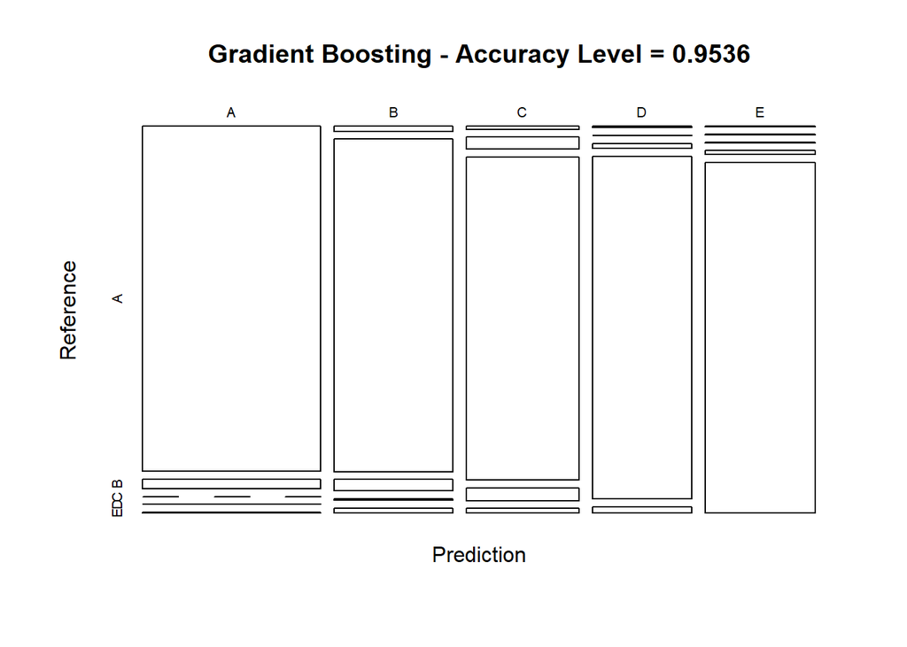

From the Confusion Matrix’s CI, we get a 95% accuracy most of the times so the GBM is satisfying our needs.

**Now we need to compare how each model went through our validation set, here we’ll only consider the last two models GBM and RFM since the DTM never made the necessary accuracy in the first place**

```r
RF_pred_conf$overall
```

```
##       Accuracy          Kappa  AccuracyLower  AccuracyUpper   AccuracyNull
##      0.9913332      0.9890370      0.9890255      0.9932638      0.2844762
## AccuracyPValue  McnemarPValue
##      0.0000000            NaN
```

```r
GBM_pred_conf$overall
```

```
##       Accuracy          Kappa  AccuracyLower  AccuracyUpper   AccuracyNull
##   9.536069e-01   9.412928e-01   9.487177e-01   9.581555e-01   2.844762e-01
## AccuracyPValue  McnemarPValue
##   0.000000e+00   1.970294e-15
```

After this comparison it is clear that the Random Forests Model has more precision than the Gradient boost model, so we’ll be applying the RFM for the final prediction on the test set

## Final Prediction

```r
Final_RF_prediction <- predict(RF_modfit, test_set )
Final_RF_prediction
```

```
##  [1] B A B A A E D B A A B C B A E E A B B B
## Levels: A B C D E
```